# 3 Ingesting data

ZJ

2020-07-20

## Ingesting Data

Very important topic. `{disk.frame}` can handle large dataset on disk, but the data needs to be in `{disk.frame}` format.

### Reading CSVs

`{disk.frame}` tries to be take advantage of multi-threading and multiple workers when possible.

The best way to read CSV is to use

```
csv_to_disk.frame("some/path.csv", outdir = "some.df")
```

For example, I will write a CSV and then read it back

```r
suppressPackageStartupMessages(library(disk.frame))
library(data.table)
# Write a file
data.table::fwrite(nycflights13::flights, "tmp.csv")
```

reading ONE CSV

```r
flights.df <- csv_to_disk.frame("tmp.csv", "some_location.df")
flights.df
```

```
## path: "some_location.df"
## nchunks: 6
## nrow (at source): 336776
## ncol (at source): 19
## nrow (post operations): ???
## ncol (post operations): ???
```

```r
head(flights.df)
```

```
##    year month day dep_time sched_dep_time dep_delay arr_time sched_arr_time
## 1: 2013     1   1      517            515         2      830            819
## 2: 2013     1   1      533            529         4      850            830
## 3: 2013     1   1      542            540         2      923            850
## 4: 2013     1   1      544            545        -1     1004           1022
## 5: 2013     1   1      554            600        -6      812            837
## 6: 2013     1   1      554            558        -4      740            728
##    arr_delay carrier flight tailnum origin dest air_time distance hour minute
## 1:        11      UA   1545  N14228    EWR  IAH      227     1400    5     15
## 2:        20      UA   1714  N24211    LGA  IAH      227     1416    5     29
## 3:        33      AA   1141  N619AA    JFK  MIA      160     1089    5     40
## 4:       -18      B6    725  N804JB    JFK  BQN      183     1576    5     45
## 5:       -25      DL    461  N668DN    LGA  ATL      116      762    6      0
## 6:        12      UA   1696  N39463    EWR  ORD      150      719    5     58
##               time_hour
## 1: 2013-01-01T10:00:00Z
## 2: 2013-01-01T10:00:00Z
## 3: 2013-01-01T10:00:00Z
## 4: 2013-01-01T10:00:00Z
## 5: 2013-01-01T11:00:00Z
## 6: 2013-01-01T10:00:00Z
```

### `{disk.frame}` read CSV logic

`{disk.frame}` has multiple CSV backends: `{data.table}`, `{readr}`, and `{LaF}`. It uses some rather complicated logic to determine which backend to use. In general, it prefers `{data.table}` and roughly follows this logic

- If `{disk.frame}` deems your CSV to be small enough to fit in RAM it will use data.table’s `fread`
- If the file is too large, it will use `{bigreadr}` to SPLIT the file into smaller files and then read the smaller files simultaneously. In practice this was found to be the fastest approach.

How to invoke the different back-ends?

```r
csv_to_disk.frame(..., backend = c("data.table", "readr", "LaF"))
```

Lear more:

```r
?csv_to_disk.frame
```

I try to make documentation as good as possible. See

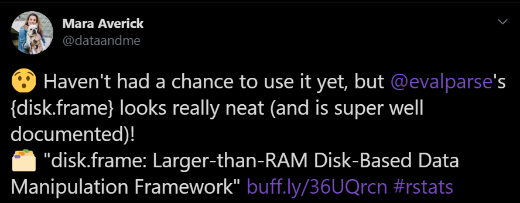

dataandme’s kind words

For more details, please refer to [the “Ingesting Data” article on the diskframe.com website](https://diskframe.com/articles/04-ingesting-data.html)

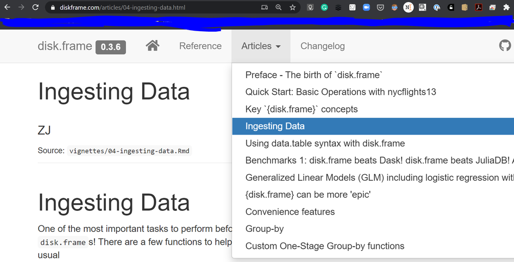

### Reading multiple CSVs with the same columns

```r
# write two CSV files
data.table::fwrite(nycflights13::flights, "tmp1.csv")
data.table::fwrite(nycflights13::flights, "tmp2.csv")

flights_doubled.df <- csv_to_disk.frame(c("tmp1.csv", "tmp2.csv"), "some_location.df")
```

```
## csv_to_disk.frame: Reading multiple input files.
```

```
## Please use `colClasses = `  to set column types to minimize the chance of a failed read
```

```
## -- Converting CSVs to disk.frame -- Stage 1 of 2:
```

```
## Converting 2 CSVs to 6 disk.frames each consisting of 6 chunks
```

```
## -- Converting CSVs to disk.frame -- Stage 1 or 2 took: 0.770s elapsed (0.500s cpu)
```

```
## -- Converting CSVs to disk.frame -- Stage 2 of 2:
```

```
## Row-binding the 6 disk.frames together to form one large disk.frame:
```

```
## Creating the disk.frame at some_location.df
```

```
## Appending disk.frames:
```

```
## Stage 2 of 2 took: 0.750s elapsed (0.460s cpu)
```

```
## Stage 1 & 2 in total took: 1.520s elapsed (0.960s cpu)
```

```r
flights_doubled.df
```

```
## path: "some_location.df"
## nchunks: 6
## nrow (at source): 673552
## ncol (at source): 19
## nrow (post operations): ???
## ncol (post operations): ???
```

**Discussion: What are some dangers to watch out for when reading multiple CSVs?**

### Ingesting other data types?

The one function I would recommend using is `add_chunk`. It adds a file chunk to a `disk.frame`. Example use-cases include:

1. New data comes in on a regular basis (e.g. month), `add_chunk(exisint_disk.frame, new_chunk.data.frame)`
2. Reading from a database chunk by chunk and convert it to `disk.frame` format

Because the `disk.frame` is nothing but `fst` files in a folder. You can be creative and create the `fst` files `1.fst`, `2.fst`, `3.fst` simultaneously.

#### “Stream” data for a DBMS chunk-by-chunk

I will show an SQLite example. Other DBMS follows the same tricks

```r
library(RSQLite)

library(DBI)
# Create an ephemeral in-memory RSQLite database
con <- dbConnect(RSQLite::SQLite(), ":memory:")
dbWriteTable(con, "flights", nycflights13::flights)

res <- dbSendQuery(con, "SELECT * FROM flights LIMIT 100 OFFSET 0")
dbFetch(res)
```

```
##     year month day dep_time sched_dep_time dep_delay arr_time sched_arr_time
## 1   2013     1   1      517            515         2      830            819
## 2   2013     1   1      533            529         4      850            830
## 3   2013     1   1      542            540         2      923            850
## 4   2013     1   1      544            545        -1     1004           1022
## 5   2013     1   1      554            600        -6      812            837
## 6   2013     1   1      554            558        -4      740            728
## 7   2013     1   1      555            600        -5      913            854
## 8   2013     1   1      557            600        -3      709            723
## 9   2013     1   1      557            600        -3      838            846
## 10  2013     1   1      558            600        -2      753            745
## 11  2013     1   1      558            600        -2      849            851
## 12  2013     1   1      558            600        -2      853            856
## 13  2013     1   1      558            600        -2      924            917
## 14  2013     1   1      558            600        -2      923            937
```

[output cut: 288 more lines]

```r
db_to_disk.frame <- function(con, tbl, ..., chunksize = 1e6, verbose = FALSE) {
  suppressWarnings(
    row_count <- DBI::dbSendQuery(con, glue::glue("SELECT count(*) from {tbl}")) %>% DBI::dbFetch()
  )
  row_count = row_count[[1]]

  offsets = seq.int(0, row_count, by=chunksize)

  suppressWarnings(
    res <- dbSendQuery(con, glue::glue("SELECT * FROM {tbl} ORDER BY ROW_NUMBER() over () LIMIT {as.integer(chunksize)} OFFSET 0"))
  )

  suppressWarnings(res <- dbFetch(res))

  df_out = as.disk.frame(res, ...)

  purrr::walk(offsets[-1], function(offset) {
    sql_statement = glue::glue("SELECT * FROM {tbl} ORDER BY ROW_NUMBER() over () LIMIT {as.integer(chunksize)} OFFSET {offset}")
    if(verbose) {
        print(sql_statement)
    }
    suppressWarnings({res <- dbSendQuery(con, sql_statement)})

    tmp_df = res %>% dbFetch()
    if (verbose) {
      print(glue::glue("number of rows retrieved {nrow(tmp_df)}"))
    }
    add_chunk(df_out, tmp_df)
  })

  df_out
}

flight_from_sqlite.df = db_to_disk.frame(con, "flights", chunksize = 50000)
flight_from_sqlite.df
```

```
## path: "C:\Users\RTX2080\AppData\Local\Temp\RtmpykPgsk\file4ed854726d73.df"
## nchunks: 12
## nrow (at source): 336776
## ncol (at source): 19
## nrow (post operations): ???
## ncol (post operations): ???
```

```r
head(flight_from_sqlite.df)
```

```
##    year month day dep_time sched_dep_time dep_delay arr_time sched_arr_time
## 1: 2013     1   1      517            515         2      830            819
## 2: 2013     1   1      533            529         4      850            830
## 3: 2013     1   1      542            540         2      923            850
## 4: 2013     1   1      544            545        -1     1004           1022
## 5: 2013     1   1      554            600        -6      812            837
## 6: 2013     1   1      554            558        -4      740            728
##    arr_delay carrier flight tailnum origin dest air_time distance hour minute
## 1:        11      UA   1545  N14228    EWR  IAH      227     1400    5     15
## 2:        20      UA   1714  N24211    LGA  IAH      227     1416    5     29
## 3:        33      AA   1141  N619AA    JFK  MIA      160     1089    5     40
## 4:       -18      B6    725  N804JB    JFK  BQN      183     1576    5     45
## 5:       -25      DL    461  N668DN    LGA  ATL      116      762    6      0
## 6:        12      UA   1696  N39463    EWR  ORD      150      719    5     58
##     time_hour
## 1: 1357034400
## 2: 1357034400
## 3: 1357034400
## 4: 1357034400
## 5: 1357038000
## 6: 1357034400
```

But why “stream” to `{disk.frame}` when you already have a DBMS? Good question.

In many case you don’t have to! In fact, I recommend using a DBMS if you are lucky to have one set up at work.

However, I am just showing the general technique of using `add_chunk` and how you can be creative. Also, having data in `disk.frame` means that now you have **almost** the entire R ecosystem of function open to you.